# Parole Reform

MUSA 5080 · Fall 2026

Author

Sophia Meyers

Published

November 18, 2026

# The scenario

The Georgia Department of Community Supervision is considering a risk model to guide parole decisions. Every person released to parole would get a predicted probability of being **rearrested within three years**. The department has two proposed uses:

- **Use A:** people above a threshold get **more restrictive supervision** (more check-ins, electronic monitoring, faster revocation).
- **Use B:** people above a threshold get **priority for reentry services** (housing assistance, job placement, a case manager).

The department has promised that the model **will not use race**. You’ve been hired to build it and to tell them whether that promise means what they think it means.

**What you’re turning in:** this rendered document, published in the `assignments/` folder of your portfolio.

**How this assignment works:** it has less scaffolding than earlier ones. The **Week 11 lab** (COMPAS) is your fully worked example: almost every step here has a matching step there. Where the NIJ data behaves differently from COMPAS, the instructions below tell you. Everywhere else, adapt the lab code yourself.

| A5 part | Week 11 lab step |
| --- | --- |
| 3.1 odds ratios | Step 3 |
| 4.1 predictions + confusion matrix | Steps 4–5 |
| 4.3 threshold sweep | Step 5 (`rates_at()`) |
| 4.4 ROC + AUC | Step 6 |
| 5.1–5.2 errors by race | Step 7 |
| 5.3 what carries race in | Step 8 |

Two differences from the lab: the outcome is called **`recid`** (not `two_year_recid`), and you **fit on `train` and evaluate on `test`**. In the lab we fit and scored on the same data. So every `predict()` in Parts 4 and 5 needs `newdata = test`.

# The data

The National Institute of Justice’s **Recidivism Forecasting Challenge** data: 25,835 people released from Georgia prisons to parole supervision, 2013–2015. Download the CSV from Canvas, put it in your portfolio’s `data/` folder, and rename it `nij_recidivism.csv`.

A few things to know before you start:

- **Race is recorded only as Black or white.** The data includes no one else.
- **Counts are top-coded:** “10 or more” prior felony arrests is stored as text. `parse_number()` turns it into 10, which undercounts people with many more.
- **`Residence_PUMA`** is not a census PUMA code. NIJ grouped Georgia’s PUMAs into 25 areas and numbered them 1–25 to protect privacy. You can use it to group people by place, but you can’t map it.
- **`Training_Sample`** is NIJ’s own train/test split. Use it.

# Part 1: Load and clean

```r
setwd("/Users/sophiameyers/Documents/GitHub/MUSA-5080-portfolio")
```

```r
getwd()
```

```
[1] "/Users/sophiameyers/Documents/GitHub/MUSA-5080-portfolio/assignments"
```

```r
library(tidyverse)

nij <- read_csv("../data/nij-challenge2021_full_dataset.csv") %>%
  mutate(
    recid = as.integer(Recidivism_Within_3years == "Yes"),
    male               = as.integer(Gender == "M"),
    age_group          = factor(Age_at_Release),
    prison_years       = factor(Prison_Years,
                                levels = c("Less than 1 year", "1-2 years",
                                           "Greater than 2 to 3 years",
                                           "More than 3 years")),
    prior_fel_arrests  = parse_number(Prior_Arrest_Episodes_Felony),
    prior_misd_arrests = parse_number(Prior_Arrest_Episodes_Misd),
    puma               = factor(Residence_PUMA)
  )

train <- nij %>% filter(Training_Sample == 1)
test  <- nij %>% filter(Training_Sample == 0)
```

**1.1** How many people are in `train` and in `test`? What share of each was rearrested within three years?

```r
nij_summary <- bind_rows(
  train %>% summarize(
    sample = "Training",
    n = n(),
    rearrested = sum(recid == 1, na.rm = TRUE),
    share_rearrested = mean(recid, na.rm = TRUE)
  ),
  test %>% summarize(
    sample = "Test",
    n = n(),
    rearrested = sum(recid == 1, na.rm = TRUE),
    share_rearrested = mean(recid, na.rm = TRUE)
  )
)

nij_summary
```

```
# A tibble: 2 × 4
  sample       n rearrested share_rearrested
  <chr>    <int>      <int>            <dbl>
1 Training 18028      10421            0.578
2 Test      7807       4483            0.574
```

*There are 18,028 people in train and 7807 people in test. The percentage of recidivism within the training set is 57% and this is also true for my test data set.*

**1.2** Look at `Gang_Affiliated`. How many values are missing, and who are they? (Hint: cross-tabulate it with `Gender`.) What would happen to your sample if you added this variable to a model without handling the missing values?

```r
nij %>%
  count(Gender, Gang_Affiliated, .drop = FALSE)
```

```
# A tibble: 3 × 3
  Gender Gang_Affiliated     n
  <chr>  <chr>           <int>
1 F      <NA>             3167
2 M      No              18730
3 M      Yes              3938
```

*Gang_affiliated variable has 3,167 missing values that all belong to women. All men have a binary observation, whereas women dont. If I added this variable to a logistic regressison model without handling the missing values, R woudl automatically drop them, removing all women from the sample.*

# Part 2: What would you know at the moment of decision?

The parole decision happens **at release**. Some columns in this file were recorded **during** the three years of supervision that followed.

**2.1** Sort every predictor column into one of two lists. You don’t need code; use `names(nij)` and the column names.

```r
names(nij)
```

[output not shown]

[output cut: 16 more lines]

| Known at release | Recorded during supervision (leakage) |
| --- | --- |
| Gender | Violations_ElectronicMonitoring |
| Race | Violations_Instruction |
| Age_at_Release | Violations_FailToReport |
| Residence_PUMA | Violations_MoveWithoutPermission |
| Gang_Affiliated | Delinquency_Reports |
| Supervision_Risk_Score_First | Program_Attendances |
| Supervision_Level_First | Program_UnexcusedAbsences |
| Education_Level | Residence_Changes |
| Dependents | Avg_Days_per_DrugTest |
| Prison_Offense | DrugTests_THC_Positive |
| Prison_Years | DrugTests_Cocaine_Positive |
| Prior_Arrest_Episodes_Felony | DrugTests_Meth_Positive |
| Prior_Arrest_Episodes_Misd | DrugTests_Other_Positive |
| Prior_Arrest_Episodes_Violent | Percent_Days_Employed |
| Prior_Arrest_Episodes_Property | Jobs_Per_Year |
| Prior_Arrest_Episodes_Drug | Employment_Exempt |
| Prior_Arrest_Episodes_DVCharges | Recidivism_Within_3years |
| Prior_Arrest_Episodes_GunCharges | Recidivism_Arrest_Year1 |
| Prior_Conviction_Episodes_Felony | Recidivism_Arrest_Year2 |
| Prior_Conviction_Episodes_Misd | Recidivism_Arrest_Year3 |
| Prior_Conviction_Episodes_Viol |  |
| Prior_Conviction_Episodes_Prop |  |
| Prior_Conviction_Episodes_Drug |  |
| Prior_Revocations_Parole |  |
| Prior_Revocations_Probation |  |
| Condition_MH_SA |  |
| Condition_Cog_Ed |  |
| Condition_Other |  |

**2.2** Pick one variable from the right-hand column and explain, in two sentences, why including it would make your model look better than it really is.

*Violations_FailToReport records whether someone failed to report during their parole supervision, which would not be known at the time of their release. Including this variable would give the model information about events that occurred after release, improving its predictive accuracy and making it appear more effective than it would be when making actual parole decisions.*

# Part 3: Build a race-blind model

Start from this model.

```r
base_fit <- glm(recid ~ male + age_group + prison_years +
                  prior_fel_arrests + prior_misd_arrests,
                family = binomial,
                data = train)

summary(base_fit)
```

```
Call:
glm(formula = recid ~ male + age_group + prison_years + prior_fel_arrests +
    prior_misd_arrests, family = binomial, data = train)

Coefficients:
                                       Estimate Std. Error z value Pr(>|z|)
(Intercept)                           -0.031637   0.078824  -0.401  0.68815
male                                   0.454123   0.049610   9.154  < 2e-16 ***
age_group23-27                        -0.505516   0.070835  -7.137 9.57e-13 ***
age_group28-32                        -1.062281   0.072975 -14.557  < 2e-16 ***
age_group33-37                        -1.448176   0.076123 -19.024  < 2e-16 ***
age_group38-42                        -1.678820   0.081802 -20.523  < 2e-16 ***
age_group43-47                        -1.910151   0.084204 -22.685  < 2e-16 ***
age_group48 or older                  -2.290828   0.080526 -28.448  < 2e-16 ***
prison_years1-2 years                 -0.124180   0.041760  -2.974  0.00294 **
prison_yearsGreater than 2 to 3 years -0.304194   0.049685  -6.122 9.22e-10 ***
prison_yearsMore than 3 years         -0.319948   0.047298  -6.765 1.34e-11 ***
prior_fel_arrests                      0.167507   0.006573  25.483  < 2e-16 ***
prior_misd_arrests                     0.131496   0.008719  15.081  < 2e-16 ***
---
Signif. codes:  0 '***' 0.001 '**' 0.01 '*' 0.05 '.' 0.1 ' ' 1

(Dispersion parameter for binomial family taken to be 1)

    Null deviance: 24551  on 18027  degrees of freedom
Residual deviance: 21940  on 18015  degrees of freedom
AIC: 21966

Number of Fisher Scoring iterations: 4
```

**3.1** Exponentiate the coefficients. Interpret the odds ratio for `prior_fel_arrests` in one sentence, using the word *odds* correctly.

```r
exp(coef(base_fit))
```

```
                          (Intercept)                                  male
                            0.9688582                             1.5747917
                       age_group23-27                        age_group28-32
                            0.6031942                             0.3456664
                       age_group33-37                        age_group38-42
                            0.2349986                             0.1865940
                       age_group43-47                  age_group48 or older
                            0.1480580                             0.1011826
                prison_years1-2 years prison_yearsGreater than 2 to 3 years
                            0.8832206                             0.7377176
        prison_yearsMore than 3 years                     prior_fel_arrests
                            0.7261868                             1.1823530
                   prior_misd_arrests
                            1.1405337
```

*Holding all other variables constant, each additional prior felony arrest is associated with an approximately 18.2% increase in the odds of being rearrested within three years.*

**3.2** Constant on the odds, not on the probability. Use `predict(..., type = "response")` with `newdata` to compute the predicted probability for two made-up people, then add one prior felony arrest to each:

- a man, age 23–27, 1–2 years in prison, 2 prior felony arrests, 1 misdemeanor arrest
- a man, age 48 or older, 1–2 years in prison, 2 prior felony arrests, 1 misdemeanor arrest

How much does one more arrest change each person’s probability? Why are the two changes different?

```r
people <- tibble(
  male               = c(1, 1),
  age_group          = factor(c("23-27", "48 or older"), levels = levels(nij$age_group)),
  prison_years       = factor(c("1-2 years", "1-2 years"), levels = levels(nij$prison_years)),
  prior_fel_arrests  = c(2, 2),
  prior_misd_arrests = c(1, 1)
)

prob_original <- predict(
  base_fit,
  newdata = people,
  type = "response"
)

people_more_arrests <- people %>%
  mutate(prior_fel_arrests = prior_fel_arrests + 1)

prob_more_arrests <- predict(
  base_fit,
  newdata = people_more_arrests,
  type = "response"
)

tibble(
  age_group = people$age_group,
  original_probability = prob_original,
  new_probability = prob_more_arrests,
  probability_change = prob_more_arrests - prob_original
)
```

```
# A tibble: 2 × 4
  age_group   original_probability new_probability probability_change
  <fct>                      <dbl>           <dbl>              <dbl>
1 23-27                      0.564           0.605             0.0406
2 48 or older                0.179           0.204             0.0259
```

*Adding one prior felony arrest increases the predicted probability of rearrest for both. For the person aged 23–27, the probability increases from approximately 56.4% to 60.5%. For the person aged 48 or older, it increases from approximately 17.9% to 20.4%. The changes differ because logistic regression estimates a constant change in log-odds, not a constant change in probability. Since the two individuals have different starting probabilities, the same increase in felony arrests produces different changes in predicted probability.*

**3.3** Improve the model. Add at least **three** predictors from your “known at release” list. Keep race out. Call it `my_fit`. In two or three sentences, say what you added and why you expected each one to help.

**WarningCheck for missing values before you add a variable**

Some columns have blanks: `Prison_Offense` is missing for about 1 in 8 people, and `Supervision_Level_First` for about 1 in 15. If you add one as it is, `glm()` **silently drops** those people from training, and `predict()` returns `NA` for them in `test`. Then `mean()` gives `NA` in Parts 4–6, and `table()` quietly leaves them out. Either leave the variable out, or keep the blanks as their own category, for example `mutate(offense = replace_na(Prison_Offense, "Missing"))`. Whichever you choose, say so in your answer.

```r
nij %>%
  summarise(
    education_missing = sum(is.na(Education_Level)),
    dependents_missing = sum(is.na(Dependents)),
    violent_arrests_missing = sum(is.na(Prior_Arrest_Episodes_Violent)),
    prior_convictions_missing = sum(is.na(Prior_Conviction_Episodes_Felony))
  )
```

```
# A tibble: 1 × 4
  education_missing dependents_missing violent_arrests_missing
              <int>              <int>                   <int>
1                 0                  0                       0
# ℹ 1 more variable: prior_convictions_missing <int>
```

```r
my_fit <- glm(
  recid ~ male + age_group + prison_years +
    prior_fel_arrests + prior_misd_arrests +
    Education_Level + Dependents + Prior_Arrest_Episodes_Violent,
  family = binomial,
  data = train
)

summary(my_fit)
```

```
Call:
glm(formula = recid ~ male + age_group + prison_years + prior_fel_arrests +
    prior_misd_arrests + Education_Level + Dependents + Prior_Arrest_Episodes_Violent,
    family = binomial, data = train)

Coefficients:
                                        Estimate Std. Error z value Pr(>|z|)
(Intercept)                            -0.158903   0.088430  -1.797   0.0723
male                                    0.431941   0.050170   8.609  < 2e-16
age_group23-27                         -0.509398   0.071200  -7.155 8.40e-13
age_group28-32                         -1.062095   0.074046 -14.344  < 2e-16
age_group33-37                         -1.448498   0.077763 -18.627  < 2e-16
age_group38-42                         -1.676709   0.083819 -20.004  < 2e-16
age_group43-47                         -1.904676   0.085951 -22.160  < 2e-16
age_group48 or older                   -2.274231   0.082265 -27.645  < 2e-16
prison_years1-2 years                  -0.139227   0.041936  -3.320   0.0009
prison_yearsGreater than 2 to 3 years  -0.323143   0.049939  -6.471 9.76e-11
prison_yearsMore than 3 years          -0.336232   0.048462  -6.938 3.98e-12
prior_fel_arrests                       0.163964   0.006709  24.440  < 2e-16
prior_misd_arrests                      0.127043   0.008987  14.136  < 2e-16
Education_LevelHigh School Diploma      0.220422   0.046848   4.705 2.54e-06
Education_LevelLess than HS diploma     0.081217   0.048410   1.678   0.0934
Dependents1                             0.049432   0.046282   1.068   0.2855
Dependents2                             0.055045   0.048908   1.125   0.2604
Dependents3 or more                     0.017243   0.042845   0.402   0.6874
Prior_Arrest_Episodes_Violent1          0.051679   0.040154   1.287   0.1981
Prior_Arrest_Episodes_Violent2          0.096951   0.052132   1.860   0.0629
Prior_Arrest_Episodes_Violent3 or more  0.059441   0.053948   1.102   0.2705

(Intercept)                            .
male                                   ***
age_group23-27                         ***
age_group28-32                         ***
age_group33-37                         ***
age_group38-42                         ***
age_group43-47                         ***
age_group48 or older                   ***
prison_years1-2 years                  ***
prison_yearsGreater than 2 to 3 years  ***
prison_yearsMore than 3 years          ***
prior_fel_arrests                      ***
prior_misd_arrests                     ***
Education_LevelHigh School Diploma     ***
Education_LevelLess than HS diploma    .
Dependents1
Dependents2
Dependents3 or more
Prior_Arrest_Episodes_Violent1
Prior_Arrest_Episodes_Violent2         .
Prior_Arrest_Episodes_Violent3 or more
---
Signif. codes:  0 '***' 0.001 '**' 0.01 '*' 0.05 '.' 0.1 ' ' 1

(Dispersion parameter for binomial family taken to be 1)

    Null deviance: 24551  on 18027  degrees of freedom
Residual deviance: 21906  on 18007  degrees of freedom
AIC: 21948

Number of Fisher Scoring iterations: 4
```

*I added Education_Level, Dependents, and Prior_Arrest_Episodes_Violent to the model. I expected education level to help capture differences in socioeconomic background, dependents to reflect differences in personal responsibilities, and prior violent arrests to provide additional information about someone’s criminal history. None of these variables had missing values, so adding them did not cause glm() to drop any observations.*

# Part 4: Choosing a threshold

**4.1** Add a column `p_hat` to `test` with predicted probabilities from `my_fit`, and a column `pred_50` that flags anyone at or above 0.5. (Parts 5 and 6 use these column names.) Then make a confusion matrix and compute sensitivity and specificity.

```r
test <- test %>%
  mutate(
    p_hat = predict(my_fit, newdata = test, type = "response"),
    pred_50 = p_hat >= 0.5
  )

table(
  Predicted = test$pred_50,
  Actual = test$recid
)
```

```
         Actual
Predicted    0    1
    FALSE 1497  803
    TRUE  1827 3680
```

```r
sum(test$pred_50 == TRUE & test$recid == 1) /
  sum(test$recid == 1)
```

```
[1] 0.8208789
```

```r
sum(test$pred_50 == FALSE & test$recid == 0) /
  sum(test$recid == 0)
```

```
[1] 0.450361
```

*At the 0.5 threshold, the model correctly identifies approximately 82.1% of people who are rearrested within three years (sensitivity). However, it correctly identifies only 45.0% of people who are not rearrested (specificity). This means the model catches most rearrests but also incorrectly labels many people who are not rearrested as high risk.*

**4.2** What share of the test set does your model label “high risk” at 0.5? Compare it to the share actually rearrested. What does that tell you about 0.5 as a default for this data?

*57% actually get rearested (3608+803/7807) and 70% were predicted to be rearrested (3608+1827/7807). This means it favors sensitivity.*

**4.3** Compute sensitivity and specificity for every threshold from 0.30 to 0.80 in steps of 0.05, and plot both lines on one chart with threshold on the x-axis.

Hint: in the lab you called `rates_at()` three times by hand. Here you need eleven thresholds. `map_dfr(thresholds, function(t) ...)` runs the same code once per threshold and stacks the results into one data frame. Your version will need `p_hat` instead of `pred`, and `recid` instead of `two_year_recid`.

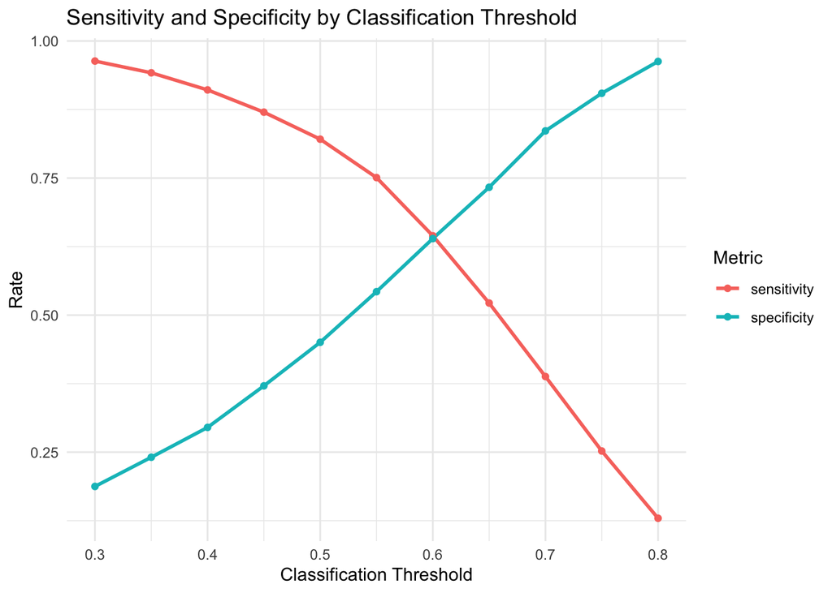

```r
thresholds <- seq(0.30, 0.80, by = 0.05)

rates <- map_dfr(thresholds, function(t) {
  predicted <- test$p_hat >= t

  tibble(
    threshold = t,
    sensitivity = sum(predicted & test$recid == 1) / sum(test$recid == 1),
    specificity = sum(!predicted & test$recid == 0) / sum(test$recid == 0)
  )
})

rates %>%
  pivot_longer(
    cols = c(sensitivity, specificity),
    names_to = "metric",
    values_to = "rate"
  ) %>%
  ggplot(aes(x = threshold, y = rate, color = metric)) +
  geom_line(linewidth = 1) +
  geom_point() +
  labs(
    title = "Sensitivity and Specificity by Classification Threshold",
    x = "Classification Threshold",
    y = "Rate",
    color = "Metric"
  ) +
  theme_minimal()
```

**4.4** Plot the ROC curve for `my_fit` on the test set with `pROC` and report the AUC. In one sentence: what does the AUC tell you, and what doesn’t it tell you about the decision the department has to make?

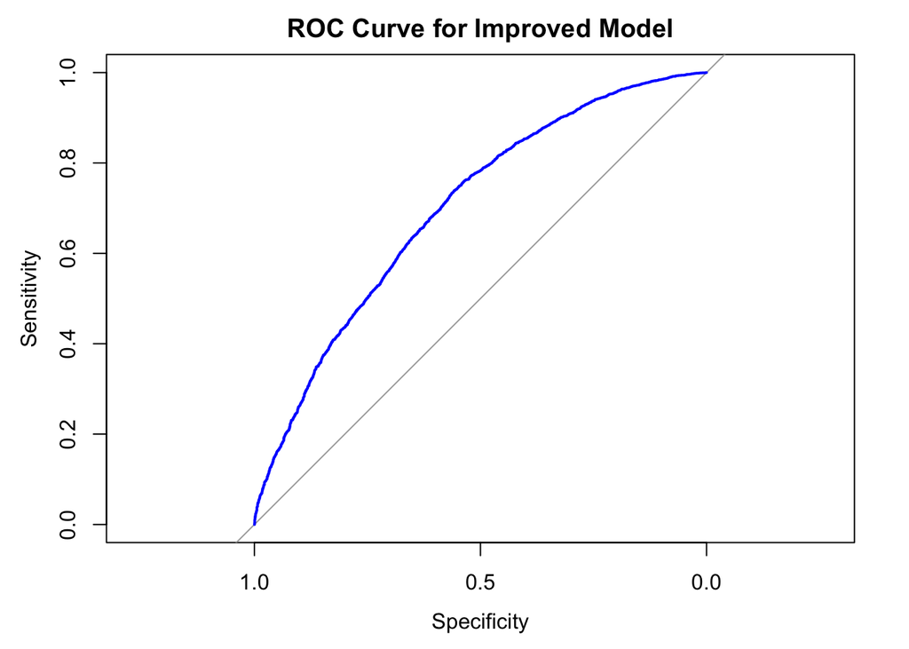

```r
library(pROC)

roc_fit <- roc(test$recid, test$p_hat)

plot(
  roc_fit,
  main = "ROC Curve for Improved Model",
  col = "blue",
  lwd = 2
)
```

```r
auc(roc_fit)
```

```
Area under the curve: 0.6994
```

*The AUC of 0.6994 indicates that the model has moderate ability to distinguish between individuals who will be rearrested and those who will not. However, the AUC does not identify the best classification threshold or account for the relative costs of false positives and false negatives, which the department must consider when deciding how to classify individuals as high risk.*

# Part 5: Is it race-blind?

Race isn’t in your model. Now check the errors by race on the **test set**.

**5.1** At the threshold of 0.5, compute for each race: the share labeled high risk, the share actually rearrested, the **false positive rate** (labeled high risk, not rearrested, out of everyone not rearrested), and the **false negative rate**.

```r
race_results <- test %>%
  group_by(Race) %>%
  summarise(
    share_high_risk = mean(pred_50),
    share_rearrested = mean(recid),
    false_positive_rate = sum(pred_50 & recid == 0) / sum(recid == 0),
    false_negative_rate = sum(!pred_50 & recid == 1) / sum(recid == 1),
    n = n()
  )

race_results
```

```
# A tibble: 2 × 6
  Race  share_high_risk share_rearrested false_positive_rate false_negative_rate
  <chr>           <dbl>            <dbl>               <dbl>               <dbl>
1 BLACK           0.729            0.582               0.589               0.170
2 WHITE           0.673            0.564               0.498               0.192
# ℹ 1 more variable: n <int>
```

**5.2** Repeat 5.1 at two other thresholds from your sweep. Does the gap between groups close, stay, or flip?

```r
race_threshold_results <- map_dfr(c(0.40, 0.60), function(t) {
  test %>%
    mutate(predicted = p_hat >= t) %>%
    group_by(Race) %>%
    summarise(
      threshold = t,
      share_high_risk = mean(predicted),
      share_rearrested = mean(recid),
      false_positive_rate = sum(predicted & recid == 0) / sum(recid == 0),
      false_negative_rate = sum(!predicted & recid == 1) / sum(recid == 1),
      .groups = "drop"
    )
})

race_threshold_results
```

```
# A tibble: 4 × 6
  Race  threshold share_high_risk share_rearrested false_positive_rate
  <chr>     <dbl>           <dbl>            <dbl>               <dbl>
1 BLACK       0.4           0.848            0.582               0.747
2 WHITE       0.4           0.789            0.564               0.648
3 BLACK       0.6           0.543            0.582               0.385
4 WHITE       0.6           0.497            0.564               0.328
# ℹ 1 more variable: false_negative_rate <dbl>
```

*The differences between racial groups persist at both alternative thresholds. At 0.40, Black individuals have a higher false positive rate (74.7%) than White individuals (64.8%), while at 0.60 the gap remains (38.5% versus 32.8%). The false negative rate is higher for White individuals at both thresholds. Increasing the threshold reduces false positives but increases false negatives for both groups. Therefore, changing the threshold does not eliminate the differences between groups.*

**5.3** Investigate at least two candidates by comparing their distributions by race. Possibilities include age, prior arrests, prison offense, and place (`puma`). Show your evidence with a table or chart for each.

```r
test %>%
  group_by(Race, age_group) %>%
  summarise(n = n(), .groups = "drop") %>%
  group_by(Race) %>%
  mutate(share = n / sum(n))
```

```
# A tibble: 14 × 4
# Groups:   Race [2]
   Race  age_group       n  share
   <chr> <fct>       <int>  <dbl>
 1 BLACK 18-22         437 0.0964
 2 BLACK 23-27        1043 0.230
 3 BLACK 28-32         903 0.199
 4 BLACK 33-37         707 0.156
 5 BLACK 38-42         500 0.110
 6 BLACK 43-47         369 0.0814
 7 BLACK 48 or older   575 0.127
 8 WHITE 18-22         175 0.0535
 9 WHITE 23-27         522 0.159
10 WHITE 28-32         630 0.192
11 WHITE 33-37         589 0.180
12 WHITE 38-42         453 0.138
13 WHITE 43-47         393 0.120
14 WHITE 48 or older   511 0.156
```

```r
test %>%
  group_by(Race) %>%
  summarise(
    mean_prior_felony_arrests = mean(prior_fel_arrests),
    median_prior_felony_arrests = median(prior_fel_arrests),
    .groups = "drop"
  )
```

```
# A tibble: 2 × 3
  Race  mean_prior_felony_arrests median_prior_felony_arrests
  <chr>                     <dbl>                       <dbl>
1 BLACK                      5.70                           5
2 WHITE                      5.84                           6
```

*I compared age distributions and prior felony arrests across racial groups. Black individuals in the test set were more concentrated in younger age groups, with approximately 32.5% under age 28 compared with 21.3% of White individuals. Since younger age groups have higher predicted rearrest probabilities in my model, this difference may contribute to the higher share of Black individuals classified as high risk. However, prior felony arrests were similar across groups, with Black individuals averaging 5.70 and White individuals averaging 5.84. This suggests that age distribution may help explain some of the disparity, while prior felony arrests do not appear to explain much of it.*

# Part 6: Does it hold up in places it hasn’t seen?

Use leave-one-PUMA-group-out cross-validation **on the training set**, the same recipe as Week 10’s leave-one-district-out.

```r
pumas <- levels(train$puma)

cv_puma <- map_dfr(pumas, function(u) {
  cv_train <- train %>% filter(puma != u)
  cv_test  <- train %>% filter(puma == u)

  fit <- glm(formula(my_fit), family = binomial, data = cv_train)

  cv_test %>%
    mutate(pred = as.integer(predict(fit, newdata = cv_test,
                                     type = "response") >= 0.5)) %>%
    summarize(puma       = u,
              n          = n(),
              share_black = mean(Race == "BLACK"),
              accuracy   = mean(pred == recid),
              fpr        = sum(pred == 1 & recid == 0) / sum(recid == 0))
})
```

**6.1** Plot each PUMA group’s false positive rate against its share of Black parolees. What pattern, if any, do you see?

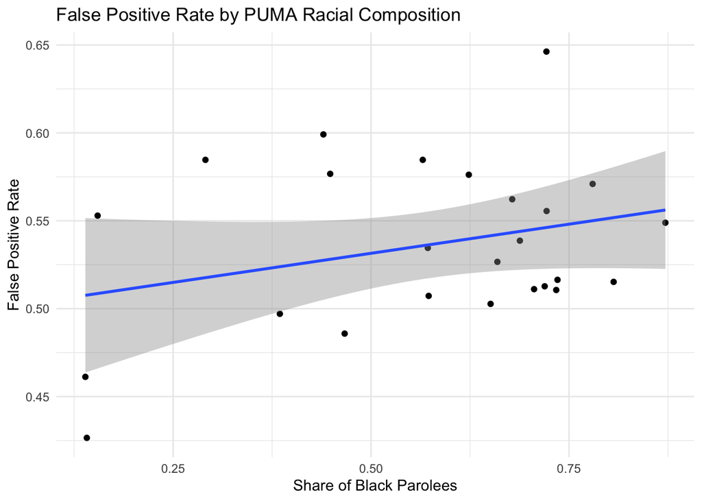

```r
ggplot(cv_puma, aes(x = share_black, y = fpr)) +
  geom_point() +
  geom_smooth(method = "lm", se = TRUE) +
  labs(
    title = "False Positive Rate by PUMA Racial Composition",
    x = "Share of Black Parolees",
    y = "False Positive Rate"
  ) +
  theme_minimal()
```

*The plot shows a weak positive relationship between the share of Black parolees in a PUMA and its false positive rate. PUMAs with larger shares of Black parolees generally tend to have higher false positive rates, although there is considerable variation across geographic groups. This suggests that the model’s errors may be related to the racial composition of the geographic areas in which it is applied, rather than being consistent across locations.*

**6.2** If you put `puma` itself into the model as a predictor, would that make the model more or less race-blind? Make an argument using what you found in 6.1. (You may test it, but you don’t have to.)

*Including puma as a predictor would likely make the model less race-blind because geographic location can act as a proxy for racial composition. My results show a slightly positive relationship between the share of Black parolees in a PUMA and its false positive rate. Including PUMA could allow the model to learn geographic patterns that are associated with race, potentially reinforcing existing disparities even though race itself is excluded from the model.*

# Part 7: The memo

Write a memo (**400–600 words**) to the Department of Community Supervision. It must:

1. **Pick a threshold for Use A and a threshold for Use B**, and defend each using the cost of a false positive and a false negative *in that use*. Cite your own numbers from Parts 4 and 5.
2. Tell them **whether “the model doesn’t use race” means it treats Black and white parolees the same**, using your Part 5 results.
3. End with one sentence: **“I would / would not deploy this for Use *, unless* .”**

Write to a deputy commissioner, not to a statistician. No code, no jargon you haven’t explained.

To: Deputy Commissioner, Georgia Department of Community Supervision  
From: Sophia

The recidivism prediction model offers a potential tool for helping the Department allocate supervision resources and reentry services. However, its predictions should be used carefully because the choice of classification threshold affects both the accuracy of decisions and their consequences for individuals. I recommend using different thresholds depending on the purpose of the prediction.

For Use A, assigning more restrictive supervision, I recommend a threshold of 0.60. This use carries significant consequences for individuals, including additional check-ins, electronic monitoring, and potentially faster revocation. A false positive could result in someone who would not have been rearrested facing unnecessary restrictions. Therefore, it is important to limit false positives, even if doing so means missing some individuals who will be rearrested. At the 0.60 threshold, the false positive rate was 38.5% for Black individuals and 32.8% for White individuals, compared with 58.9% and 49.8%, respectively, at the 0.50 threshold. Although the higher threshold reduces false positives, it also increases false negatives, meaning more individuals who will be rearrested are incorrectly classified as low risk. This tradeoff is important, but restrictive supervision should require additional evidence beyond a model prediction.

For Use B, prioritizing reentry services, I recommend a threshold of 0.40. In this situation, a false positive is less harmful because it means someone receives additional assistance they may not necessarily need. A false negative, however, could mean someone misses access to housing assistance, job placement, or a dedicated case manager that could help support their successful reintegration. At the 0.40 threshold, the false negative rate was only 8.0% for Black individuals and 10.2% for White individuals. This is preferable for a program intended to identify as many people who may benefit from additional support as possible. Although this threshold produces more false positives, the consequences are less severe than incorrectly restricting someone’s freedom.

Excluding race from the model does not mean that Black and White parolees are treated equally by its predictions. At the 0.50 threshold, 72.9% of Black individuals were labeled high risk compared with 67.3% of White individuals, even though their actual rearrest rates were relatively similar at 58.2% and 56.4%. The false positive rate was also higher for Black individuals (58.9%) than White individuals (49.8%). These differences demonstrate that other characteristics, including age and geographic location, can contribute to unequal outcomes even when race is not explicitly included. The model’s AUC of 0.6994 also indicates only moderate ability to distinguish between individuals who will and will not be rearrested.

The Department should treat these predictions as one source of information rather than definitive judgments about individuals. It should regularly evaluate differences in errors across racial groups and ensure that people have access to meaningful human review. I would not deploy this for Use A, unless additional review and ongoing evaluations of racial disparities are established.